# Random Variable

Kateřina Večerková vecerkok@vscht.cz

2025-01-22

```r
install.packages("ggplot2")
install.packages("dplyr")
library(ggplot2)
library(dplyr)
```

# Random Variable, PMF, PDF, and CDF

## Introduction

In this tutorial, we will explore the concept of a random variable in statistics, understand its types, and see how to work with random variables in R. By the end of this session, you should be able to define random variables, differentiate between discrete and continuous types, and model probability distributions using R.

## What is a Random Variable?

A random variable is a numerical outcome of a random process. For example, when you toss a coin, the outcome (heads or tails) can be assigned numerical values.

- **Discrete Random Variable:** A variable that can take on a finite or countable number of values (e.g., number of heads in 5 coin tosses).
- **Continuous Random Variable:** A variable that can take on an infinite number of values within a given range (e.g., the height of students in a class).

## Discrete Random Variables

Discrete random variables can take on a finite set of possible values. For example, rolling a die can result in one of the numbers 1 through 6.

```r
# simulate a die roll
set.seed(42) # fix randomisation seed so that we'll all get the same result
rolls <- sample(1:6, size = 1000, replace = TRUE)
table(rolls)
```

```
## rolls
##   1   2   3   4   5   6
## 172 192 164 157 153 162
```

### **Probability Mass Function (PMF) (Pravděpodobnostní funkce)**

- **Definition:** Probability mass function is the probability distribution of a discrete random variable, and provides the possible values and their associated probabilities. Simply said it’s a function that gives the probability that a discrete random variable is exactly equal to some value.
- **Properties:** PMFs are non-negative for every possible outcome and the probabilities sum to one.

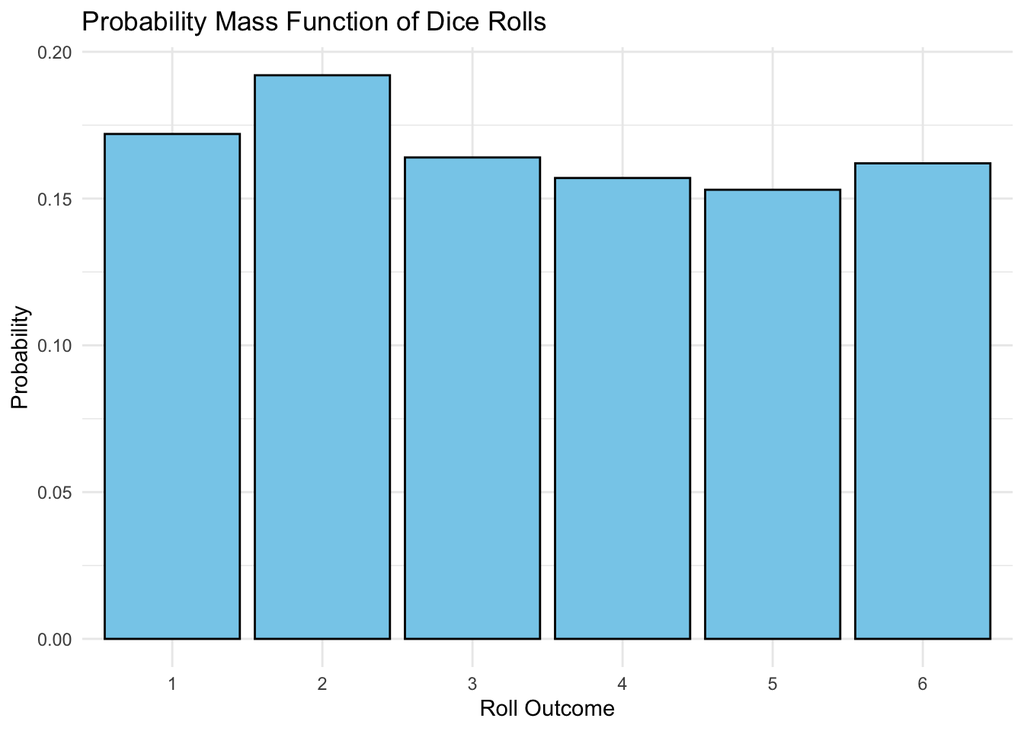

```r
# plot the PMF of the die rolls above
rolls_data <- as.data.frame(table(rolls))
colnames(rolls_data) <- c("roll", "frequency")
rolls_data$roll <- as.factor(rolls_data$roll)
rolls_data$probability <- rolls_data$frequency / sum(rolls_data$frequency)

ggplot(rolls_data, aes(x = roll, y = probability)) +
  geom_bar(stat = "identity", fill = "skyblue", color = "black") +
  labs(title = "Probability Mass Function of Dice Rolls",
       x = "Roll Outcome",
       y = "Probability") +
  theme_minimal()
```

### **Cumulative Distribution Function (CDF) for Discrete Variables**

- **Definition:** Cumulative Distribution Function (CDF) for Discrete Variables
- **Relationship to PMF:** The CDF is derived from the PMF by summation.
- **Properties:** CDF is right-continuous non-decreasing, the values range between 0 and 1, in minus inf it limits to 0 and in plus inf to 1.

[output not shown]

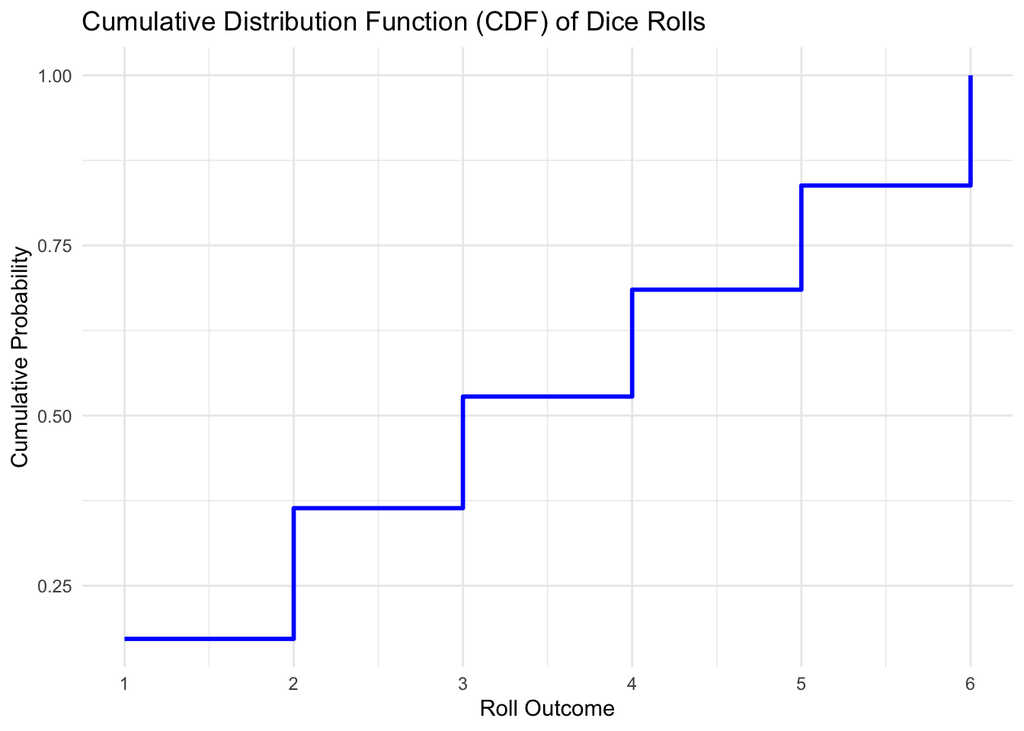

```r
# calculate the cumulative probabilities (CDF)
rolls_data$cumulative_probability <- cumsum(rolls_data$probability)

# plot the CDF using a step plot
ggplot(rolls_data, aes(x = as.numeric(as.character(roll)), y = cumulative_probability)) +
  geom_step(color = 'blue', size = 1) +
  labs(title = "Cumulative Distribution Function (CDF) of Dice Rolls",
       x = "Roll Outcome",
       y = "Cumulative Probability") +
  scale_x_continuous(breaks = 1:6) +  # Ensure x-axis only shows discrete values from 1 to 6
  theme_minimal()
```

**Warning! The plot above is not completely accurate, can you tell why?**

## Continuous Random Variables

Continuous random variables can take on any value within a range. For example, the height of students in a class.

```r
# simulate heights of students in a class
heights <- rnorm(1000, mean=170, sd=10)
heights[1:10] # look at first ten values
```

```
##  [1] 153.9746 156.4540 139.8207 178.3124 172.5110 174.6229 178.4479 169.5803
##  [9] 158.9442 175.6378
```

### **Probability Density Function (PDF) (Hustota pravděpodobnosti)**

- **Definition:** The Probability Density Function (PDF) describes the probability distribution of a continuous random variable by indicating how the probabilities are distributed over the values of the variable. Unlike the PMF, the PDF does not give probabilities directly; instead, the probability that the variable falls within a certain interval is found by calculating the area under the curve of the PDF over that interval. The probability at any single exact point is zero, continuous random variables are calculated over intervals, which involved finding the area under the curve of the PDF across that range.
- **Properties:** PDF is always non-negative for all possible values, the total area equals 1.

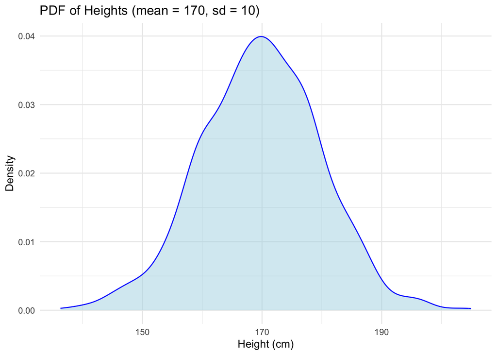

```r
# plotting the PDF of the height of students above
ggplot(data.frame(heights = heights), aes(x = heights)) +
  geom_density(color = 'blue', fill = 'lightblue', alpha = 0.5) +  # Density plot for the PDF
  labs(title = "PDF of Heights (mean = 170, sd = 10)",
       x = "Height (cm)", y = "Density") +
  theme_minimal()
```

### **Cumulative Distribution Function (CDF) for Continuous Variables**

- **Definition:** The Cumulative Distribution Function (CDF) for continuous random variables is a function that gives the probability that the random variable X takes a value less than or equal to x.
- **Relationship to PDF:** The CDF is derived from the PDF by integration.
- **Properties:** CDF is right-continuous non-decreasing, the values range between 0 and 1, in minus inf it limits to 0 and in plus inf to 1.

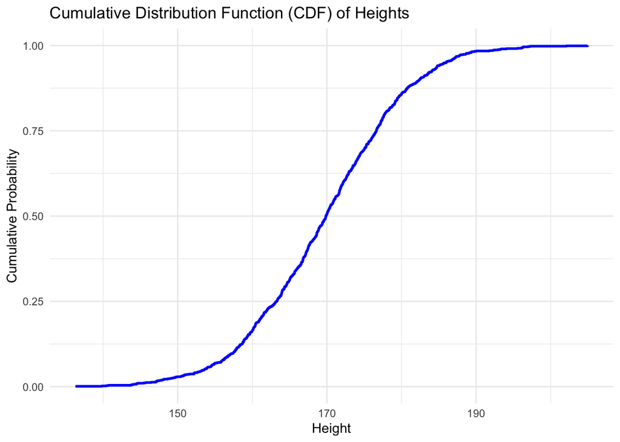

```r
# calculate the CDF
heights_data <- data.frame(heights = heights)
heights_data <- heights_data %>% arrange(heights)
heights_data$cdf <- (1:nrow(heights_data)) / nrow(heights_data)

# plot the CDF
ggplot(heights_data, aes(x = heights, y = cdf)) +
  geom_step(color = 'blue', size = 1) +
  labs(title = "Cumulative Distribution Function (CDF) of Heights",
       x = "Height",
       y = "Cumulative Probability") +
  theme_minimal()
```